# Health and Economic Effects of Severe Weather Events across USA

### Synopsis

In this report I have examined the effects of severe weather events in United States on the population health and country’s economy. To investigate this hypothesis, I have obtained the weather data through U.S. National Oceanic and Atmospheric Administration’s (NOAA) storm database which is recorded for the years from 1950 to 2011. I have meausred harmful effects of these events through injuires and fatalties and found that **Tornado** and **Excessive Heat** are most harmful with respect to population health. I have also examined the economic effects of these events through the damages caused to property and crops and found that **Floods** and **Hurricane/Typhoons** are the main causes.

### Data Processing

I have used R function of *bzfile()* and *read.csv()* to load this weather data into R.

```r
if(file.exists('repdata-data-StormData.csv.bz2')){
  data <- read.csv(bzfile("repdata-data-StormData.csv.bz2"), header = TRUE)
}
```

To see the dimensions of data and structure of data loaded

```r
library("ggplot2")
library("dplyr")

dim(data)
```

```
## [1] 902297     37
```

```r
str(data)
```

```
## 'data.frame':    902297 obs. of  37 variables:
##  $ STATE__   : num  1 1 1 1 1 1 1 1 1 1 ...
##  $ BGN_DATE  : Factor w/ 16335 levels "1/1/1966 0:00:00",..: 6523 6523 4242 11116 2224 2224 2260 383 3980 3980 ...
##  $ BGN_TIME  : Factor w/ 3608 levels "00:00:00 AM",..: 272 287 2705 1683 2584 3186 242 1683 3186 3186 ...
##  $ TIME_ZONE : Factor w/ 22 levels "ADT","AKS","AST",..: 7 7 7 7 7 7 7 7 7 7 ...
##  $ COUNTY    : num  97 3 57 89 43 77 9 123 125 57 ...
##  $ COUNTYNAME: Factor w/ 29601 levels "","5NM E OF MACKINAC BRIDGE TO PRESQUE ISLE LT MI",..: 13513 1873 4598 10592 4372 10094 1973 23873 24418 4598 ...
##  $ STATE     : Factor w/ 72 levels "AK","AL","AM",..: 2 2 2 2 2 2 2 2 2 2 ...
##  $ EVTYPE    : Factor w/ 985 levels "   HIGH SURF ADVISORY",..: 834 834 834 834 834 834 834 834 834 834 ...
##  $ BGN_RANGE : num  0 0 0 0 0 0 0 0 0 0 ...
##  $ BGN_AZI   : Factor w/ 35 levels "","  N"," NW",..: 1 1 1 1 1 1 1 1 1 1 ...
##  $ BGN_LOCATI: Factor w/ 54429 levels ""," Christiansburg",..: 1 1 1 1 1 1 1 1 1 1 ...
##  $ END_DATE  : Factor w/ 6663 levels "","1/1/1993 0:00:00",..: 1 1 1 1 1 1 1 1 1 1 ...
##  $ END_TIME  : Factor w/ 3647 levels ""," 0900CST",..: 1 1 1 1 1 1 1 1 1 1 ...
##  $ COUNTY_END: num  0 0 0 0 0 0 0 0 0 0 ...
```

[output cut: 23 more lines]

From here we can see that we only need the folloing variables for our analysis:

- EVTYPE
- FATALITIES
- INJURIES
- PROPDMG
- PROPDMGEXP
- CROPDMG
- CROPDMGEXP

So I selected these variables from *data* and strored the resulting data in a new variable called *selected_data*.

```r
selected_data <- select(data, EVTYPE,FATALITIES,INJURIES,PROPDMG,PROPDMGEXP,CROPDMG,CROPDMGEXP)
```

## Results

### Across the United States, which types of events are most harmful with respect to population health?

For the analysis of harmful effects on public health, I have aggredated number of injuries and fatalties with respect to weather events and then calculated the top 10 events with most number of harmful effects. This can also be seen in the plot shown below.

```r
harm_pop_health <- aggregate(FATALITIES + INJURIES  ~ EVTYPE, selected_data, sum, na.rm = T)
names(harm_pop_health) <- c("EVENTS", "HARM")
harm_pop_health <- arrange(harm_pop_health, desc(HARM))
harm_pop_health <- harm_pop_health[1:10, ]

harm_pop_health
```

```
##               EVENTS  HARM
## 1            TORNADO 96979
## 2     EXCESSIVE HEAT  8428
## 3          TSTM WIND  7461
## 4              FLOOD  7259
## 5          LIGHTNING  6046
## 6               HEAT  3037
## 7        FLASH FLOOD  2755
## 8          ICE STORM  2064
## 9  THUNDERSTORM WIND  1621
## 10      WINTER STORM  1527
```

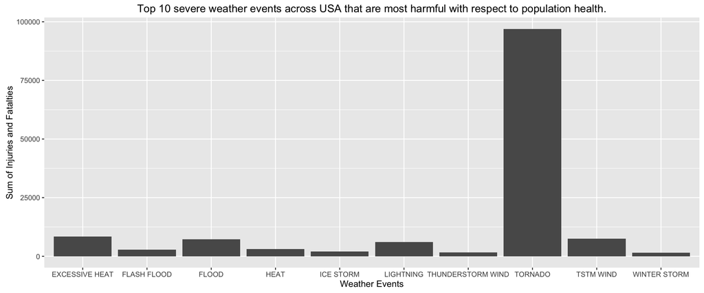

```r
g <- ggplot(harm_pop_health, aes(EVENTS, HARM)) + geom_bar(stat="identity")
g + labs(title = "Top 10 severe weather events across USA that are most harmful with respect to population health.",
         x = "Weather Events", y="Sum of Injuries and Fatalties" )
```

### Across the United States, which types of events have the greatest economic consequences?

For the analysis of economical effects due to weather events, I have first transformed the *PROPDMGEXP* and *CROPDMGEXP* and created 2 new variables *PROP_DATA* and *CROP_DATA*

```r
transform_data <- function(dataset = selected_data){
  dataset$PROPDMGEXP <- as.character(dataset$PROPDMGEXP)
  dataset$PROPDMGEXP <- as.character(dataset$PROPDMGEXP)
  dataset$PROPDMGEXP = gsub("\\-|\\+|\\?","0",dataset$PROPDMGEXP)
  dataset$PROPDMGEXP = gsub("B|b", "9", dataset$PROPDMGEXP)
  dataset$PROPDMGEXP = gsub("M|m", "6", dataset$PROPDMGEXP)
  dataset$PROPDMGEXP = gsub("K|k", "3", dataset$PROPDMGEXP)
  dataset$PROPDMGEXP = gsub("H|h", "2", dataset$PROPDMGEXP)
  dataset$PROPDMGEXP <- as.numeric(dataset$PROPDMGEXP)
  dataset$PROPDMGEXP[is.na(dataset$PROPDMGEXP)] = 0
  dataset$PROP_DATA<- dataset$PROPDMG * 10^dataset$PROPDMGEXP

  dataset$CROPDMGEXP <- as.character(dataset$CROPDMGEXP)
  dataset$CROPDMGEXP = gsub("\\-|\\+|\\?","0",dataset$CROPDMGEXP)
  dataset$CROPDMGEXP = gsub("B|b", "9", dataset$CROPDMGEXP)
  dataset$CROPDMGEXP = gsub("M|m", "6", dataset$CROPDMGEXP)
  dataset$CROPDMGEXP = gsub("K|k", "3", dataset$CROPDMGEXP)
  dataset$CROPDMGEXP = gsub("H|h", "2", dataset$CROPDMGEXP)
  dataset$CROPDMGEXP <- as.numeric(dataset$CROPDMGEXP)
  dataset$CROPDMGEXP[is.na(dataset$CROPDMGEXP)] = 0
  dataset$CROP_DATA<- dataset$CROPDMG * 10^dataset$CROPDMGEXP

  return(dataset)
}

selected_data <- transform_data(selected_data)
```

I then aggreated the data obtained from these newly created property and crop vaiables with respect to the events and then calculated the top 10 events with most number of economic effects caused due to these severe weather events.

```r
enonomic_harm <- aggregate(PROP_DATA + CROP_DATA ~ EVTYPE, selected_data, sum, na.rm = T)
names(enonomic_harm) <- c("EVENTS", "HARM")
enonomic_harm <- arrange(enonomic_harm, desc(HARM))
enonomic_harm <- enonomic_harm[1:10, ]

enonomic_harm
```

```
##               EVENTS         HARM
## 1              FLOOD 150319678257
## 2  HURRICANE/TYPHOON  71913712800
## 3            TORNADO  57362333946
## 4        STORM SURGE  43323541000
## 5               HAIL  18761221986
## 6        FLASH FLOOD  18243991078
## 7            DROUGHT  15018672000
## 8          HURRICANE  14610229010
## 9        RIVER FLOOD  10148404500
## 10         ICE STORM   8967041360
```

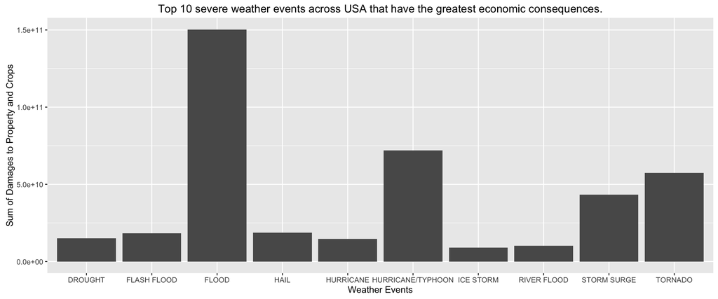

```r
g <- ggplot(enonomic_harm, aes(EVENTS, HARM)) + geom_bar(stat="identity")
g + labs(title = "Top 10 severe weather events across USA that have the greatest economic consequences.",
         x = "Weather Events", y="Sum of Damages to Property and Crops")
```